# Doing Data Science Case Study 1 Unit 6, Week 6

Najeeb Zaidi

July 27, 2016

# World Bank Country Data: Comparative Analysis of GDP vs Income Categories for Select Groups

## Introduction

This analysis attempts to profile 190 Countries listed in the World Bank dataset, comparing Countries ranked per GDP amounts and the Income Groups in respective countries. The analysis required base data to be extracted and cleaned from from two different source files.

[output not shown]

#### Data Sources:

The data sources used for this presentation are:

```
* http://data.worldbank.org/data-catalog/GDP-ranking-table
** alternate: https://d396qusza40orc.cloudfront.net/getdata%2Fdata%2FGDP.csv

* http://data.worldbank.org/data-catalog/ed-stats
** alternate: https://d396qusza40orc.cloudfront.net/getdata%2Fdata%2FEDSTATS_Country.csv
```

#### Tools & Libraries / (Reproducible Research Standards):

We have used the RMarkdown and RStudio to create this HTML and to ensure version control and standards of reproducible research.

The R package version used for this analysis was 3.3.1 and other than the standard libraries, the external R packages employed for this purpose are:

```
 * library(dtplyr)    : allows the data cleaning, rank ordering & table manipulations;
 * library(regex)     : allows data cleaning / vector conversions from chr to numeric etc;
 * library(stats)     : allows computing averages and quantiles on cleaned data;
 * library(ggplot2)   : allows graphics and basic data visualizations;
 * library(plotrix)   : allows additional graphing capability;
 * library(rmarkdown) : allows source files reproducible;
 * library(tabplot)   : allows data visualization for large datasets
```

## 1. Reading Raw Data, Cleaning & Review of Exclusions

The data files were read directly from referred web source and matched on the basis of country shortcodes (ID). In this process we found that the GDP data file (sources file 1) contained 190 records while the Education Level data (source file 2) contained 234 records.

Data Source 1: Procure and read GDP data from target source

```
## [1] 190   4
```

```
## 'data.frame':    190 obs. of  4 variables:
##  $ ID     : chr  "USA" "CHN" "JPN" "DEU" ...
##  $ Ranking: chr  "1" "2" "3" "4" ...
##  $ Country: chr  "United States" "China" "Japan" "Germany" ...
##  $ GDP    : chr  " 16,244,600 " " 8,227,103 " " 5,959,718 " " 3,428,131 " ...
```

```
##      ID Ranking                        Country   GDP
## 182 GRD     178                        Grenada  767
## 183 KNA     178            St. Kitts and Nevis  767
## 184 VCT     180 St. Vincent and the Grenadines  713
## 185 WSM     181                          Samoa  684
## 186 COM     182                        Comoros  596
## 187 DMA     183                       Dominica  480
## 188 TON     184                          Tonga  472
## 189 FSM     185          Micronesia, Fed. Sts.  326
## 190 STP     186          SC#o TomC) and Principe  263
## 191 PLW     187                          Palau  228
## 192 MHL     188               Marshall Islands  182
## 193 KIR     189                       Kiribati  175
## 194 TUV     190                         Tuvalu   40
```

The first data set is cleaned by removing columns with NAs and a known corrected header to manage subsequent analysis, but the Ranking and GDP columns are still in character format.

Secondly, if we observe the tail end 13 observations of our first file, we find that Rows 182 & 183 (i.e. 13th and 12th observations from the bottom have the same Ranking as well as the GDP amount. We will review this at a later stage in out analysis.

Data Source 2: Procure and read Education Levels data from target source

```r
EduData <- read.csv("https://d396qusza40orc.cloudfront.net/getdata%2Fdata%2FEDSTATS_Country.csv", header = TRUE, sep = ",", stringsAsFactors = FALSE)
names(EduData) <- c("ID","Country","Income_Group", "Region", "Lending_Group", "Other")
dim(EduData)
```

```
## [1] 234  31
```

```r
str(EduData)
```

```
## 'data.frame':    234 obs. of  31 variables:
##  $ ID           : chr  "ABW" "ADO" "AFG" "AGO" ...
##  $ Country      : chr  "Aruba" "Principality of Andorra" "Islamic State of Afghanistan" "People's Republic of Angola" ...
##  $ Income_Group : chr  "High income: nonOECD" "High income: nonOECD" "Low income" "Lower middle income" ...
##  $ Region       : chr  "Latin America & Caribbean" "Europe & Central Asia" "South Asia" "Sub-Saharan Africa" ...
##  $ Lending_Group: chr  "" "" "IDA" "IDA" ...
##  $ Other        : chr  "" "" "HIPC" "" ...
##  $ NA           : chr  "Aruban florin" "Euro" "Afghan afghani" "Angolan kwanza" ...
##  $ NA           : chr  "2000" "Register based" "1979" "1970" ...
##  $ NA           : chr  "" "" "MICS, 2003" "MICS, 2001, MIS, 2006/07" ...
##  $ NA           : chr  "" "" "Fiscal year end: March 20; reporting period for national accounts data: FY." "" ...
##  $ NA           : chr  "1995" "" "2002/2003" "1997" ...
##  $ NA           : int  NA NA NA NA 1996 NA NA 1996 NA NA ...
##  $ NA           : int  NA NA NA NA 1993 NA 1993 1993 NA NA ...
##  $ NA           : chr  "" "" "VAB" "VAP" ...
```

[output cut: 17 more lines]

As we review the second file it requires more cleaning effort. We will pick only the columns that we need for our current review context.

Our analysis of GDP levels per country vs the Income Groups requires that the two files are merged for a subset where the Country IDs match between the two data files andthe GDP and Income Group data is available. For this we use the following coding process. The number of records that match on ID are given below :

```r
# Merge the 2 files by ID
EduData2 <- EduData[,c(1:3)]
row.names(EduData2) = NULL
Data <- merge(GDPData2, EduData2, by = "ID")

str(Data)
```

```
## 'data.frame':    189 obs. of  6 variables:
##  $ ID          : chr  "ABW" "AFG" "AGO" "ALB" ...
##  $ Ranking     : chr  "161" "105" "60" "125" ...
##  $ Country.x   : chr  "Aruba" "Afghanistan" "Angola" "Albania" ...
##  $ GDP         : chr  " 2,584 " " 20,497 " " 114,147 " " 12,648 " ...
##  $ Country.y   : chr  "Aruba" "Islamic State of Afghanistan" "People's Republic of Angola" "Republic of Albania" ...
##  $ Income_Group: chr  "High income: nonOECD" "Low income" "Lower middle income" "Upper middle income" ...
```

```r
dim(Data)[1]
```

```
## [1] 189
```

```r
answ1 <- length(Data$ID)
message("Number of countries for which IDs match and GDP & Income Group is available are: ", answ1)
```

```
## Number of countries for which IDs match and GDP & Income Group is available are: 189
```

We have listed the exclusions made in Annex 1.

## 2. Sorting and Basic Data Visualization

As we observed in section 1, the GDP data needs to be converted to numeric format before we can sort our data into ascending GDP rank. The conversion also requires that we remove the comma character within the GDP data.

```r
sapply(Data, class)
```

```
##           ID      Ranking    Country.x          GDP    Country.y
##  "character"  "character"  "character"  "character"  "character"
## Income_Group
##  "character"
```

```r
typeof(Data$GDP)
```

```
## [1] "character"
```

```r
# Removeing the comma character within GDP string
Data$GDP <- gsub("\\,","", Data$GDP)
GDP <- Data$GDP
# Convert to numeric
Data2 <- transform(Data, GDP = as.numeric(as.character(GDP)))
typeof(Data2$GDP)
```

```
## [1] "double"
```

```r
# Sorting data frame as ascending
sort.Data2 <- Data2[order(Data2$GDP), ]

#Store sorted GDP Data in a dataframe
SortedGdpRankData2 <- data.frame(sort.Data2)
head(SortedGdpRankData2, 15)
```

```
##      ID Ranking                      Country.x GDP
## 173 TUV     190                         Tuvalu  40
## 92  KIR     189                       Kiribati 175
## 113 MHL     188               Marshall Islands 182
## 137 PLW     187                          Palau 228
## 155 STP     186          SC#o TomC) and Principe 263
## 59  FSM     185          Micronesia, Fed. Sts. 326
## 169 TON     184                          Tonga 472
## 46  DMA     183                       Dominica 480
## 39  COM     182                        Comoros 596
## 184 WSM     181                          Samoa 684
## 180 VCT     180 St. Vincent and the Grenadines 713
## 69  GRD     178                        Grenada 767
## 93  KNA     178            St. Kitts and Nevis 767
## 183 VUT     177                        Vanuatu 787
```

[output cut: 17 more lines]

```r
answ2 <- SortedGdpRankData2[13,5]
message("The 13th country by GDP ranked in ascending order is: ", answ2)
```

```
## The 13th country by GDP ranked in ascending order is: St. Kitts and Nevis
```

After our successful sorting the merged dataset, we find that ST Kitts is ranked 13th when our data is reordered as acending GDP rank.

## 3. Estimating Averages

What are the average GDP rankings for the “High income: OECD” and “High income: nonOECD” groups?  
Ensuring also the Ranking attribute is captured as numeric vector and verifying that no further missing values are for the attributes in scope for the rest of the presentation:

```r
# SortedGdpRankData2

Ranking <- SortedGdpRankData2$Ranking
Data3 <- transform(SortedGdpRankData2, Ranking = as.numeric(as.character(Ranking)))
head(Data3, 15)
```

```
##      ID Ranking                      Country.x GDP
## 173 TUV     190                         Tuvalu  40
## 92  KIR     189                       Kiribati 175
## 113 MHL     188               Marshall Islands 182
## 137 PLW     187                          Palau 228
## 155 STP     186          SC#o TomC) and Principe 263
## 59  FSM     185          Micronesia, Fed. Sts. 326
## 169 TON     184                          Tonga 472
## 46  DMA     183                       Dominica 480
## 39  COM     182                        Comoros 596
## 184 WSM     181                          Samoa 684
## 180 VCT     180 St. Vincent and the Grenadines 713
## 69  GRD     178                        Grenada 767
## 93  KNA     178            St. Kitts and Nevis 767
## 183 VUT     177                        Vanuatu 787
```

[output cut: 17 more lines]

```r
answ3.1 <- with(Data3, mean(Ranking[Income_Group == "High income: OECD"]))
message("The avg GDP Ranking for High income: OECD countries is: ", round(answ3.1, 2))
```

```
## The avg GDP Ranking for High income: OECD countries is: 32.97
```

```r
answ3.2 <- with(Data3, mean(Ranking[Income_Group == "High income: nonOECD"]))
message("The avg GDP Ranking for High income: Non-OECD countries is: ", round(answ3.2, 2))
```

```
## The avg GDP Ranking for High income: Non-OECD countries is: 91.91
```

## Basic Data Visualization

A. Review of cleaned dataset using tableplot() function.

B. Plot the GDP for all of the countries in ascending order and identifying the lowest and top 4 ranked countries.

3. Plot of GDP Rank by Income Groups

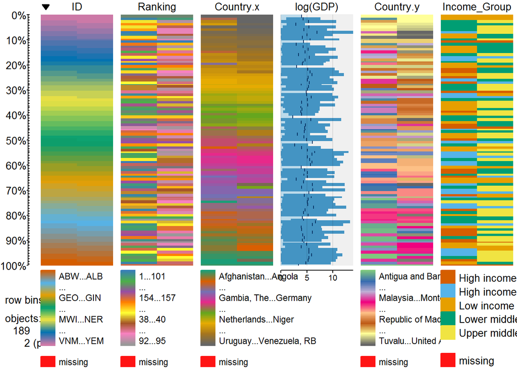

```r
tableplot(SortedGdpRankData2)
```

```r
head(SortedGdpRankData2, 15)
```

```
##      ID Ranking                      Country.x GDP
## 173 TUV     190                         Tuvalu  40
## 92  KIR     189                       Kiribati 175
## 113 MHL     188               Marshall Islands 182
## 137 PLW     187                          Palau 228
## 155 STP     186          SC#o TomC) and Principe 263
## 59  FSM     185          Micronesia, Fed. Sts. 326
## 169 TON     184                          Tonga 472
## 46  DMA     183                       Dominica 480
## 39  COM     182                        Comoros 596
## 184 WSM     181                          Samoa 684
## 180 VCT     180 St. Vincent and the Grenadines 713
## 69  GRD     178                        Grenada 767
## 93  KNA     178            St. Kitts and Nevis 767
## 183 VUT     177                        Vanuatu 787
```

[output cut: 17 more lines]

```r
typeof(SortedGdpRankData2$GDP)
```

```
## [1] "double"
```

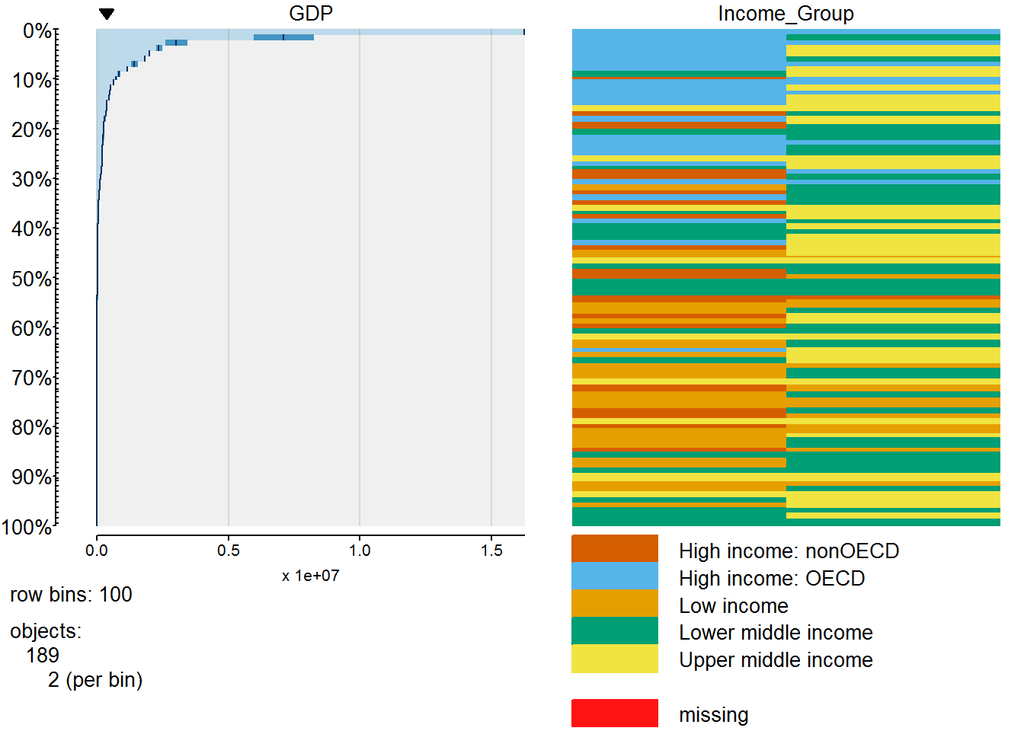

```r
# Convert GDP Sacaling
GdpScaledToBillion <- SortedGdpRankData2$GDP/1000000

tableplot(SortedGdpRankData2, select = c(GDP, Income_Group), scales = "lin")
```

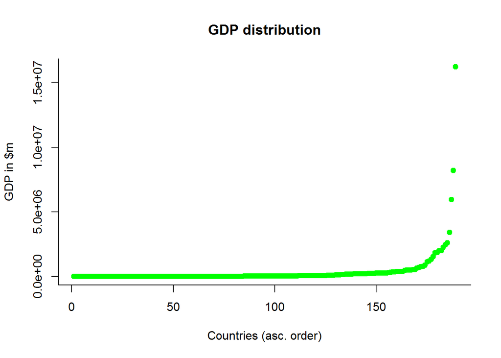

```r
# Chart without rounded GDP
c1 <- plot(SortedGdpRankData2$GDP, bty = "l", col = "green", pch = 19, main = "GDP distribution", xlab = "Countries (asc. order)", ylab = "GDP in $m")
```

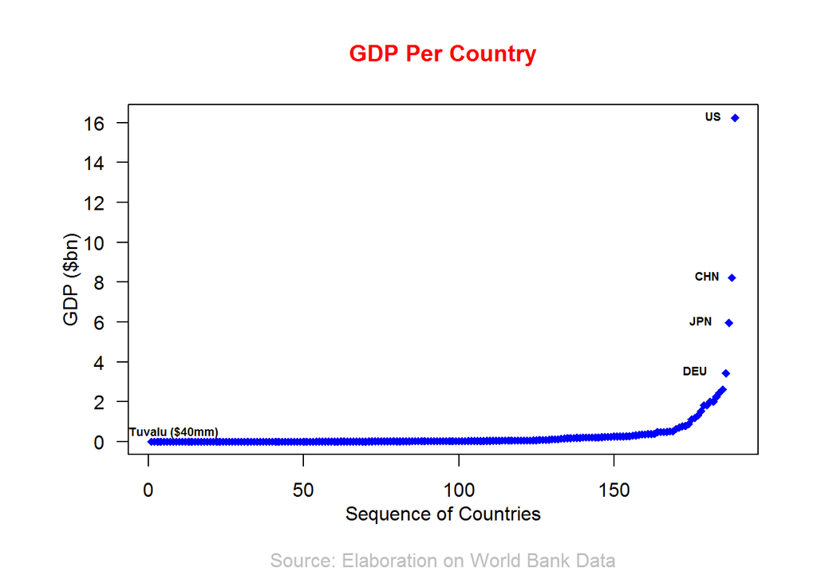

```r
# Chart plot with Corrected GDP Scale and identifying top 4 outliers
op <- par(mar = c(5,5,4,2) + 0.5)
plot(GdpScaledToBillion, bty = "l", col = "blue", pch = 18, axes = FALSE, xlab = "", ylab = "")
title(main = "GDP Per Country", col.main = "red", lines.main = 14, sub = "Source: Elaboration on World Bank Data", col.sub = "grey") ##lines.sub = 4, font.sub = 3
axis(1)
pts <- pretty(GdpScaledToBillion, n = 10)
axis(2, at = pts, las = 1)
box()
title(ylab = "GDP ($bn)", line = 2)
title(xlab = "Sequence of Countries", line = 2)
par(op)
text(182, 16.1, "US", pos = 3, xpd = F, col = "black", vfont = NULL, font = 2, cex = 0.6, offset = 0)
text(180, 8.1, "CHN", pos = 3, xpd = F, col = "black", vfont = NULL, font = 2, cex = 0.6, offset = 0)
text(178, 5.85, "JPN", pos = 3, xpd = F, col= "black", vfont = NULL, font = 2, cex=0.6, offset=0)
text(176, 3.35, "DEU", pos = 3, xpd = F, col= "black", vfont = NULL, font = 2, cex=0.6, offset=0)
text(8, 0.3, "Tuvalu ($40mm)", pos = 3, xpd = F, col = "black", vfont = NULL, font = 2, cex = 0.6, offset = 0, adj = 1)
```

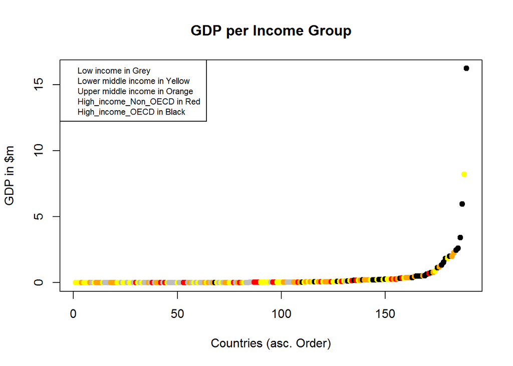

```r
# And close chart

colour <- c("grey", "yellow","orange","red","black")
col.list <- rep(0, length(SortedGdpRankData2$Income_Group))
col.list[SortedGdpRankData2$Income_Group == "Low income"] <- 1
col.list[SortedGdpRankData2$Income_Group == "Lower middle income"] <- 2
col.list[SortedGdpRankData2$Income_Group == "Upper middle income"] <- 3
col.list[SortedGdpRankData2$Income_Group == "High income: nonOECD"] <- 4
col.list[SortedGdpRankData2$Income_Group == "High income: OECD"] <- 5
p <- plot(GdpScaledToBillion, pch = 19, main = "GDP per Income Group", xlab = "Countries (asc. Order)", ylab = "GDP in $m", col = c(colour[col.list]))
legend(x = "topleft", cex = 0.7, c(" Low income in Grey ",
                               " Lower middle income in Yellow ",
                               " Upper middle income in Orange ",
                               " High_income_Non_OECD in Red ",
                               " High_income_OECD in Black "))
```

We have been able to clean, analyze and visaulize the given dataset while ensuring the results are reproducible.

### Annexes

A. List of countries excluded from original dataset

```r
GDPDataList <- GDPData2[,c(1,3)]
row.names(GDPDataList) <- NULL
B <- GDPDataList[order(GDPDataList$ID),]

EduDataList <- EduData[,c(1,2)]
row.names(EduDataList) <- NULL
A <- EduDataList[order(EduDataList$ID),]
dim(B)
```

```
## [1] 190   2
```

```r
dim(A)
```

```
## [1] 234   2
```

```r
N <- dim(A)[1]

n <- dim(B)[1]

# Implementing a double loop by column to check for equal values in two tables and write check results in a new DF table with Country Names and Check columns
DF <- data.frame(ID = rep("", N), Country = rep("", N), Check = rep("", N),stringsAsFactors = FALSE)
for (i in 1:N)  {
  j <- 1
  while (j <= n)
  {
    if (A[i,1] == B[j,1])
    {
      DF[i,1] = A[i,1]
      DF[i,2] = A[i,2]
      DF[i,3] = "yes"
      i <- i + 1
      break
    } else
    {
      DF[i,1] = A[i,1]
      DF[i,2] = A[i,2]
      DF[i,3] = "no"
      j <- j + 1
    }
  }
}

Exclusion = subset(DF, Check == "no")
row.names(Exclusion) <- NULL
Exclusion2 <- Exclusion[,c(1,2)]
Exclusion2
```

```
##     ID                                        Country
## 1  ADO                        Principality of Andorra
## 2  ASM                                 American Samoa
## 3  CHI                                Channel Islands
## 4  CYM                                 Cayman Islands
## 5  DJI                           Republic of Djibouti
## 6  EAP          East Asia & Pacific (developing only)
## 7  EAS        East Asia & Pacific (all income levels)
## 8  ECA        Europe & Central Asia (developing only)
## 9  ECS      Europe & Central Asia (all income levels)
## 10 EMU                                      Euro area
## 11 FRO                                 Faeroe Islands
## 12 GRL                                      Greenland
## 13 GUM                                           Guam
## 14 HIC                                    High income
```

[output cut: 31 more lines]

```r
# The above listed 45 countries were excluded as the 2 sources files were merged and cleaned.
```

B. Data Dictionary & Cleansing Functions Reference List [reference description]

C. General description of data trasformations [reference description]

NB: The echo = TRUE mode is intentional for this presentation. PDF version however presents only the processed output of each relevant chunk.

. .